# *DESP*: Demixing Cell State Profiles in Bulk Omics

This vignette provides a tutorial for using *DESP* to demix bulk omics data. *DESP* is a tool for predicting cell type-level omics profiles given bulk omics data and corresponding cell type compositions. In this tutorial, we present a case study from [our manuscript](https://www.biorxiv.org/content/10.1101/2023.01.19.524460v2) for identifying the proteomics profiles of transient cell states that occur in a model of cancer progression.

### What is *“demixing”*?

We use the term *demixing* to refer to separating cell type contributions to bulk omics measurements. Although the term *deconvolution* also applies to our method, we wanted to avoid that term to avoid comparisons to established *deconvolution* algorithms that have a different goal than ours, since the term *deconvolution* in bioinformatics is strongly associated with algorithms that aim to infer cell type proportions given single-cell and bulk profiles, as opposed to *DESP* which aims to predict single-cell profiles given cell type proportions and bulk profiles.

### Install R package

*DESP* is currently available through GitHub. To download R packages from GitHub, we suggest using the `install_github` function from the `devtools` package as in the below example.

```r
#install DESP package from GitHub
library(devtools)
devtools::install_github("AhmedYoussef95/DESP")
```

[output not shown]

```r
#load package
library(DESP)
```

### Formatting input data

*DESP* requires two inputs:

- Bulk omics data
  - Feature-by-sample matrix *(already pre-processed by user)*
- Cell population composition
  - Cell type-by-sample matrix containing number of cells or proportion of each cell type in each sample

Note: samples should be consistently named/ordered between the two datasets and not contain missing values. We recommend reversing log transformations before applying *DESP* to align with its additive model (‘bulk as sum of single cells’), followed by log transformation of resultant cell state-level predictions for downstream analyses as needed.

Additionally, *DESP* can improve prediction accuracy by incorporating a type of cell state similarity regularization that maintains the input cell state structure within the predictions. This regularization requires an additional matrix containing the similarities between the input cell states as described later below.

In this vignette, we will use data from the [Paul et al. (2023)](https://www.nature.com/articles/s41467-023-36122-x) publication. The data corresponds to bulk MS proteomics data and single-cell RNA-Seq data quantified in a timecourse study examining pre-cancerous cells undergoing TGF-Beta-induced EMT.

#### 1. Bulk omics data

The example bulk omics data we will use corresponds to MS proteomics measurements for 6,966 proteins quantified in 8 consecutive timepoints as the cells underwent the transition from predominantly epithelial cultures into the mesenchymal end state. The data is bundled within the package as `bulk_EMT_proteome`.

```r
#read in bulk omics data included with package
data(bulk_EMT_proteome)

#check first few rows of data
head(bulk_EMT_proteome)
```

```
#>                T0         T1          T2         T4         T5         T6
#> A2ML1  173943.333 207346.667 197733.3333 142475.000 136933.667 111757.667
#> A4GALT   2248.480   2738.367   2847.4733   3033.153   3494.933   3154.033
#> AAAS     7508.867   8816.200   7751.4000   7851.033   8112.333   8035.400
#> AADAT    4786.600   6196.467   5709.0000   4665.200   4753.400   7158.867
#> AAED1     755.110   1017.173    911.1367   1071.547   1229.793   1523.033
#> AAK1     9110.000   8485.017   8429.0333   8702.350   9864.050   8872.470
#>                T7        T8
#> A2ML1  111074.000 83271.667
#> A4GALT   3791.200  3678.633
#> AAAS     9205.000  8033.433
#> AADAT    7799.333  8092.533
#> AAED1    1367.267  1219.527
#> AAK1     9201.043  9378.833
```

#### 2. Cell state compositions

As described in [our manuscript](https://www.biorxiv.org/content/10.1101/2023.01.19.524460v2), the single-cell RNA-Seq data from this EMT study was clustered to reveal 10 distinct cell states that occur among the 1,913 cells during the transition, along with their proportions in each of the 8 timepoints. *DESP* only requires the cell state proportions as input, since it does not directly use the single-cell measurements in its predictions. The corresponding cell state composition matrix is bundled within the package as `EMT_proportions`.

```r
#read in cell state proportions included with package
data(EMT_proportions)

#examine data
EMT_proportions
```

```
#>    C1  C2 C3 C4  C5 C6 C7 C8 C9 C10
#> T0  0 168  0  0 126  2  0 45  0  26
#> T1  0 119  2  2  43  0  1 26  0  15
#> T2 15  23 61 15   2  5 95 19  2   9
#> T4 41   8 26 52   0 30 13  3  8   9
#> T5 65   0 58 61   0 45  6  3  8   1
#> T6 72   0 56 43   0 29  2  0 12   3
#> T7 80   1 50 61   0 24  1  0 15   4
#> T8 53   0 58 33   0 21  3  0 33   1
```

#### 3. (Optional) Cell type similarities

*DESP* can improve prediction accuracy by incorporating a type of cell state similarity regularization that preserves the input cell state structure. This regularization requires an additional state-by-state matrix quantifying the similarity of the input cell states. For this EMT dataset, we computed the cell state similarities as the Pearson correlation coefficient between the averaged scRNA-Seq expression profiles of each pair of cell states. This similarity matrix is bundled within the package as `EMT_cell_state_similarities`.

```r
#read in cell state similarities included with package
data(EMT_cell_state_similarities)

#examine data
EMT_cell_state_similarities
```

```
#>            C1        C2        C3        C4        C5        C6        C7
#> C1  1.0000000 0.6988424 0.9646464 0.9272561 0.7135088 0.7012349 0.9445893
#> C2  0.6988424 1.0000000 0.7353795 0.6750530 0.9587492 0.4994847 0.8518829
#> C3  0.9646464 0.7353795 1.0000000 0.8961538 0.8016715 0.6778937 0.9256087
#> C4  0.9272561 0.6750530 0.8961538 1.0000000 0.6686821 0.8475886 0.8656212
#> C5  0.7135088 0.9587492 0.8016715 0.6686821 1.0000000 0.4909571 0.8440605
#> C6  0.7012349 0.4994847 0.6778937 0.8475886 0.4909571 1.0000000 0.6319606
#> C7  0.9445893 0.8518829 0.9256087 0.8656212 0.8440605 0.6319606 1.0000000
#> C8  0.7107262 0.7888118 0.7392368 0.8212109 0.7779014 0.8178465 0.7610549
#> C9  0.9235068 0.7212930 0.9417278 0.9161153 0.7533959 0.7508876 0.8807035
#> C10 0.7233247 0.8872261 0.7556441 0.8037065 0.8729874 0.6443567 0.8109316
#>            C8        C9       C10
#> C1  0.7107262 0.9235068 0.7233247
#> C2  0.7888118 0.7212930 0.8872261
#> C3  0.7392368 0.9417278 0.7556441
#> C4  0.8212109 0.9161153 0.8037065
#> C5  0.7779014 0.7533959 0.8729874
#> C6  0.8178465 0.7508876 0.6443567
#> C7  0.7610549 0.8807035 0.8109316
#> C8  1.0000000 0.8005174 0.8905759
#> C9  0.8005174 1.0000000 0.8051266
#> C10 0.8905759 0.8051266 1.0000000
```

### Running *DESP*

Given the input matrices, DESP can be run with just one line of code:

```r
#DESP demixing to predict cell state profiles
prediction <- DESP(bulk = bulk_EMT_proteome,
                   proportions = EMT_proportions,
                   similarities = EMT_cell_state_similarities)

#examine first few rows of prediction
head(prediction)
```

```
#>               C1          C2           C3            C4            C5
#> A2ML1   0.000000 1253.641619 2.028105e+02  1.550858e+03  7.212872e-11
#> A4GALT  1.605143   16.290044 1.346555e+01  3.715697e+01  8.111112e-13
#> AAAS   35.168887   53.934074 4.779020e+00  8.050326e+01  3.010450e-12
#> AADAT  67.077420   36.290038 2.118630e-15  0.000000e+00 -3.916966e-14
#> AAED1  14.972427    5.799112 0.000000e+00 -4.005900e-13  4.194632e-16
#> AAK1   16.981746   58.863930 1.969830e+01  6.289993e+01  2.108401e-12
#>                  C6          C7            C8         C9           C10
#> A2ML1  6.103507e+02 1385.875503 -6.855062e-12  89.492060  4.519728e-13
#> A4GALT 0.000000e+00   10.345982 -2.456306e-14  47.513160  1.457437e-14
#> AAAS   0.000000e+00   45.699350 -2.902363e-13  95.196455  2.683517e-14
#> AADAT  4.013473e-16   37.559930  2.934914e-12 138.044905 -1.474562e-13
#> AAED1  5.514729e+00    5.477004  1.158118e-12   9.171785 -1.765280e-16
#> AAK1   6.429373e+01   43.883813 -3.406007e-13 115.337933  0.000000e+00
```

#### Output format

The output of *DESP* is a feature-by-cell state matrix containing the predicted feature levels for each of the pre-defined cell states, effectively demixing the measured bulk ’omics matrix into the underlying cell state ’omics profiles. This matrix can be used for standard downstream analyses such as differential expression analysis and gene set enrichment analysis and visualized using existing heatmap packages.

### Visualizing output of DESP

*DESP* includes a function for visualizing the demixing of a given feature (e.g. gene/protein) in the form of a sankey plot. The sankey plot visualizes *DESP*’s predicted cell state contributions to bulk measurements for a given feature, where ribbons connect input bulk samples (left) to cell states (right). The thickness of the ribbons corresponds to the relative contribution of the associated cell state to the measured bulk expression of the given feature in the associated bulk sample. Meanwhile, the sizes of the blocks correspond to the magnitude of the feaeture’s expression in the given bulk sample/cell state.

Below, we produce the visualization for the ‘AAK1’ protein as an example.

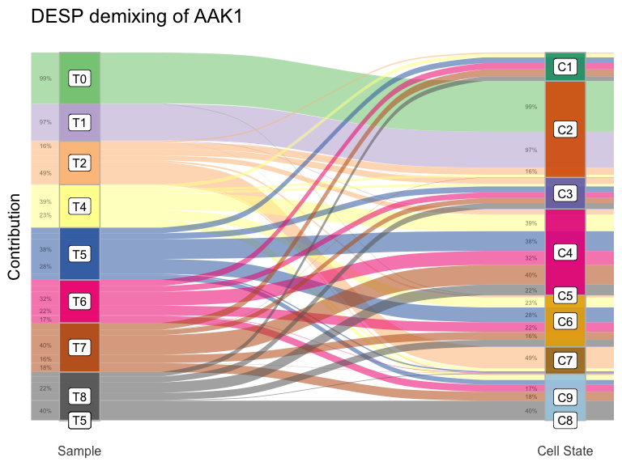

```r
#visualize results for example protein 'AAK1'
visualizeDESP(bulk = bulk_EMT_proteome,
              prediction = prediction,
              proportions = EMT_proportions,
              feature = "AAK1")
```